# Assessment : How to exercise efficiently ?

# Background

Using devices such as Jawbone Up, Nike FuelBand, and Fitbit it is now possible to collect a large amount of data about personal activity relatively inexpensively. These type of devices are part of the quantified self movement - a group of enthusiasts who take measurements about themselves regularly to improve their health, to find patterns in their behavior, or because they are tech geeks. One thing that people regularly do is quantify how much of a particular activity they do, but they rarely quantify how well they do it. In this project, your goal will be to use data from accelerometers on the belt, forearm, arm, and dumbell of 6 participants. They were asked to perform barbell lifts correctly and incorrectly in 5 different ways. More information is available from the website here: http://groupware.les.inf.puc-rio.br/har (see the section on the Weight Lifting Exercise Dataset).

# Library

```r
library(caret)
```

```r
library(rpart)
library(rpart.plot)
library(RColorBrewer)
library(rattle)
library(randomForest)
```

# Random Number Generation

Integer vector, containing the random number generator (RNG) state for random number generation in R

```r
set.seed(12345)
```

# Dataset

The training data for this project are available here:

https://d396qusza40orc.cloudfront.net/predmachlearn/pml-training.csv

The test data are available here:

https://d396qusza40orc.cloudfront.net/predmachlearn/pml-testing.csv

The data for this project come from this source: http://groupware.les.inf.puc-rio.br/har.

Download both training dataset :-

```r
curdir <-getwd()
file.url<-'http://d396qusza40orc.cloudfront.net/predmachlearn/pml-training.csv'
download.file(file.url,destfile=paste(curdir,'/pml-training.csv',sep=""))

curdir <-getwd()
file.url<-'http://d396qusza40orc.cloudfront.net/predmachlearn/pml-testing.csv'
download.file(file.url,destfile=paste(curdir,'/pml-testing.csv',sep=""))
```

Load both dataset and change the missing value “#DIV/0!” to “NA” .

```r
training <-read.csv(paste(curdir,'/pml-training.csv',sep=""),na.strings=c("NA","#DIV/0!",""))
testing <-read.csv(paste(curdir,'/pml-testing.csv',sep=""), na.strings=c("NA","#DIV/0!", ""))
```

Delete column which has missing values.

```r
training<-training[,colSums(is.na(training)) == 0]
testing <-testing[,colSums(is.na(testing)) == 0]
```

Cheking the dimension of training and test dataset :-

```r
dim(training)
```

```
## [1] 19622    60
```

```r
dim(testing)
```

```
## [1] 20 60
```

```r
training   <-training[,-c(1:7)]
testing <-testing[,-c(1:7)]
```

1. user_name
2. raw_timestamp_part_1
3. raw_timestamp_part_2
4. cvtd_timestamp
5. new_window
6. num_window

which resides on the column 1-7.

```r
training   <-training[,-c(1:7)]
testing <-testing[,-c(1:7)]
```

Check again the dimension

```r
dim(training)
```

```
## [1] 19622    46
```

```r
dim(testing)
```

```
## [1] 20 46
```

Now we obtain the several rows to preview

```r
head(training)
```

```
##   accel_belt_x accel_belt_y accel_belt_z magnet_belt_x magnet_belt_y
## 1          -21            4           22            -3           599
## 2          -22            4           22            -7           608
## 3          -20            5           23            -2           600
## 4          -22            3           21            -6           604
## 5          -21            2           24            -6           600
## 6          -21            4           21             0           603
##   magnet_belt_z roll_arm pitch_arm yaw_arm total_accel_arm gyros_arm_x
## 1          -313     -128      22.5    -161              34        0.00
## 2          -311     -128      22.5    -161              34        0.02
## 3          -305     -128      22.5    -161              34        0.02
## 4          -310     -128      22.1    -161              34        0.02
## 5          -302     -128      22.1    -161              34        0.00
## 6          -312     -128      22.0    -161              34        0.02
##   gyros_arm_y gyros_arm_z accel_arm_x accel_arm_y accel_arm_z magnet_arm_x
```

[output cut: 55 more lines]

```r
head(testing)
```

```
##   accel_belt_x accel_belt_y accel_belt_z magnet_belt_x magnet_belt_y
## 1          -38           69         -179           -13           581
## 2          -13           11           39            43           636
## 3            1           -1           49            29           631
## 4           46           45         -156           169           608
## 5           -8            4           27            33           566
## 6          -11          -16           38            31           638
##   magnet_belt_z roll_arm pitch_arm yaw_arm total_accel_arm gyros_arm_x
## 1          -382     40.7    -27.80     178              10       -1.65
## 2          -309      0.0      0.00       0              38       -1.17
## 3          -312      0.0      0.00       0              44        2.10
## 4          -304   -109.0     55.00    -142              25        0.22
## 5          -418     76.1      2.76     102              29       -1.96
## 6          -291      0.0      0.00       0              14        0.02
##   gyros_arm_y gyros_arm_z accel_arm_x accel_arm_y accel_arm_z magnet_arm_x
```

[output cut: 55 more lines]

This will do the randomize sub-sampling without replacement

```r
chunks <- createDataPartition(y=training$classe, p=0.75, list=FALSE)
chunks_training <- training[chunks, ];
chunks_testing <- training[-chunks, ]
dim(chunks_training);
```

```
## [1] 14718    46
```

```r
dim(chunks_testing);
```

```
## [1] 4904   46
```

# Visualization

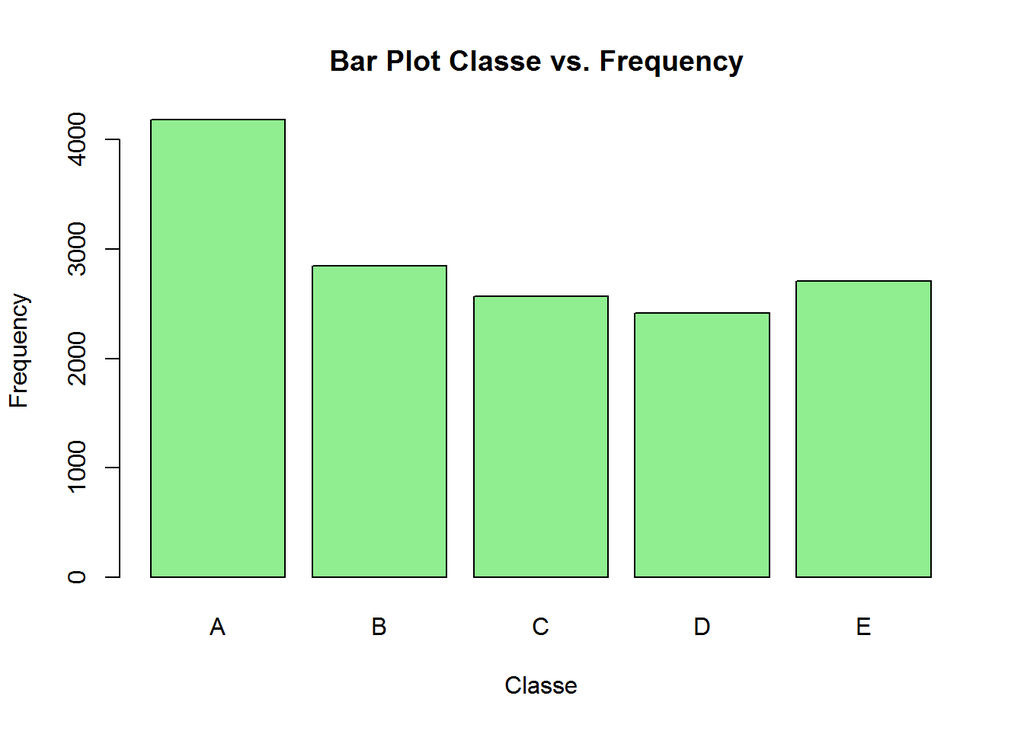

```r
plot(chunks_training$classe, col="lightgreen", main="Bar Plot Classe vs. Frequency ", xlab="Classe", ylab="Frequency")
```

The graph above shows that A ~ 4000x occurrences is most frequent while D is the lest frequent ~ 2500x occurrences

# Decision Tree

Decision Tree machine learning algorithm as a support tool that uses a tree-like graph or model of decisions and their possible consequences, including chance event outcomes, resource costs, and utility.

```r
Fit_Model_1 <- rpart(classe ~ ., data=chunks_training, method="class")
```

Displays the (Complexity) cp table for fitted model .

```r
printcp(Fit_Model_1)
```

```
##
## Classification tree:
## rpart(formula = classe ~ ., data = chunks_training, method = "class")
##
## Variables actually used in tree construction:
##  [1] accel_belt_z         accel_dumbbell_y     accel_dumbbell_z
##  [4] accel_forearm_x      gyros_dumbbell_y     magnet_arm_y
##  [7] magnet_belt_z        magnet_dumbbell_y    magnet_dumbbell_z
## [10] magnet_forearm_x     magnet_forearm_z     pitch_forearm
## [13] roll_arm             roll_dumbbell        roll_forearm
## [16] total_accel_dumbbell yaw_arm              yaw_dumbbell
## [19] yaw_forearm
##
## Root node error: 10533/14718 = 0.71565
##
## n= 14718
##
##          CP nsplit rel error  xerror      xstd
## 1  0.062826      0   1.00000 1.00000 0.0051957
## 2  0.033134      4   0.74869 0.74983 0.0057435
## 3  0.031615      5   0.71556 0.72335 0.0057553
## 4  0.021172      6   0.68395 0.68546 0.0057579
## 5  0.017089      8   0.64160 0.62708 0.0057286
## 6  0.015190      9   0.62451 0.58815 0.0056864
## 7  0.013956     10   0.60932 0.57211 0.0056637
## 8  0.013909     11   0.59537 0.55255 0.0056316
## 9  0.013102     15   0.52027 0.52995 0.0055885
## 10 0.011266     17   0.49407 0.48941 0.0054946
## 11 0.010728     20   0.46027 0.47318 0.0054508
## 12 0.010000     21   0.44954 0.46596 0.0054301
```

To visualize the decision tree , we use this fancyRpartPlot command below :-

[figure not shown]

```r
fancyRpartPlot(Fit_Model_1,main="Classification Tree")
```

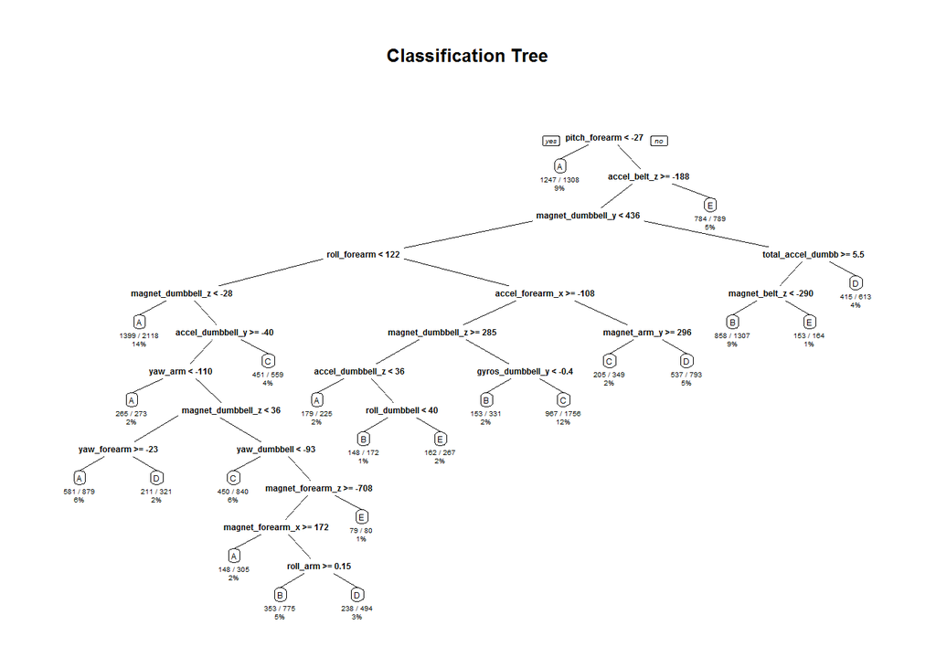

```r
rpart.plot(Fit_Model_1,main="Classification Tree",extra=102, under=TRUE, faclen=0)
```

Now we predict the fit model for test dataset .

```r
Prediction_Model1 <- predict(Fit_Model_1, chunks_testing, type = "class")
```

# Confusion Matrix

Confusion matrix, also known as a contingency table or an error matrix , is a specific table layout that allows visualization of the performance of an algorithm, typically a supervised learning one (in unsupervised learning it is usually called a matching matrix). Each column of the matrix represents the instances in a predicted class while each row represents the instances in an actual class (or vice-versa).

```r
confusionMatrix(Prediction_Model1, chunks_testing$classe)
```

```
## Confusion Matrix and Statistics
##
##           Reference
## Prediction    A    B    C    D    E
##          A 1277  217   40  115   92
##          B   61  483   83   68  160
##          C   36  150  674  141  155
##          D   19   83   56  445  128
##          E    2   16    2   35  366
##
## Overall Statistics
##
##                Accuracy : 0.6617
##                  95% CI : (0.6483, 0.6749)
##     No Information Rate : 0.2845
##     P-Value [Acc > NIR] : < 2.2e-16
##
##                   Kappa : 0.5685
##  Mcnemar's Test P-Value : < 2.2e-16
##
## Statistics by Class:
##
##                      Class: A Class: B Class: C Class: D Class: E
## Sensitivity            0.9154  0.50896   0.7883  0.55348  0.40622
## Specificity            0.8678  0.90594   0.8810  0.93024  0.98626
## Pos Pred Value         0.7335  0.56491   0.5830  0.60876  0.86936
## Neg Pred Value         0.9627  0.88491   0.9517  0.91397  0.88066
## Prevalence             0.2845  0.19352   0.1743  0.16395  0.18373
## Detection Rate         0.2604  0.09849   0.1374  0.09074  0.07463
## Detection Prevalence   0.3550  0.17435   0.2357  0.14906  0.08585
## Balanced Accuracy      0.8916  0.70745   0.8346  0.74186  0.69624
```

# Random Forest

Random forests are an ensemble learning method for classification, regression and other tasks, that operate by constructing a multitude of decision trees at training time and outputting the class that is the mode of the classes (classification) or mean prediction (regression) of the individual trees. Random forests correct for decision trees’ habit of overfitting to their training set.

```r
Fit_Model_2 <- randomForest(classe ~. , data=chunks_training)
```

Now we predict the fit model for test dataset .

```r
Prediction_Model2 <- predict(Fit_Model_2, chunks_testing, type = "class")
```

Below is the confusion matrix of the test results

```r
confusionMatrix(Prediction_Model2, chunks_testing$classe)
```

```
## Confusion Matrix and Statistics
##
##           Reference
## Prediction    A    B    C    D    E
##          A 1394    5    0    0    0
##          B    1  939    5    0    0
##          C    0    5  850   11    1
##          D    0    0    0  790    4
##          E    0    0    0    3  896
##
## Overall Statistics
##
##                Accuracy : 0.9929
##                  95% CI : (0.9901, 0.995)
##     No Information Rate : 0.2845
##     P-Value [Acc > NIR] : < 2.2e-16
##
##                   Kappa : 0.991
##  Mcnemar's Test P-Value : NA
##
## Statistics by Class:
##
##                      Class: A Class: B Class: C Class: D Class: E
## Sensitivity            0.9993   0.9895   0.9942   0.9826   0.9945
## Specificity            0.9986   0.9985   0.9958   0.9990   0.9993
## Pos Pred Value         0.9964   0.9937   0.9804   0.9950   0.9967
## Neg Pred Value         0.9997   0.9975   0.9988   0.9966   0.9988
## Prevalence             0.2845   0.1935   0.1743   0.1639   0.1837
## Detection Rate         0.2843   0.1915   0.1733   0.1611   0.1827
## Detection Prevalence   0.2853   0.1927   0.1768   0.1619   0.1833
## Balanced Accuracy      0.9989   0.9940   0.9950   0.9908   0.9969
```

# Conclusion

```r
Final_Prediction <- predict(Fit_Model_2, testing, type = "class")
```

Random Forests generally needs larger number of instances to work its randomization concept well and generalize to the novel data. In addition, in one way or another, random forests works with combination of some kind of soft linear boundaries at the decision surface

# Prediction files generator for assignment submission code

```r
pml_write_files = function(x){
  n = length(x)
  for(i in 1:n){
    filename = paste0("problem_id_",i,".txt")
    write.table(x[i],file=filename,quote=FALSE,row.names=FALSE,col.names=FALSE)
  }
}

pml_write_files(Final_Prediction)
```

# Reference

Velloso, E.; Bulling, A.; Gellersen, H.; Ugulino, W.; Fuks, H. Qualitative Activity Recognition of Weight Lifting Exercises. Proceedings of 4th International Conference in Cooperation with SIGCHI (Augmented Human ’13) . Stuttgart, Germany: ACM SIGCHI, 2013. Read more: http://groupware.les.inf.puc-rio.br/har#ixzz3lj0hACeI